# New York CitiBike Data Analysis

## Introduction

> [Citibike](https://www.citibikenyc.com/) is a privately owned public bicycle sharing system serving the New York City boroughs of the Bronx, Brooklyn, Manhattan, and Queens, as well as Jersey City, New Jersey. It is operated by Motivate (formerly Alta Bicycle Share), with former Metropolitan Transportation Authority CEO Jay Walder as chief executive until September 30th, 2018, when the company was acquired by Lyft.

> Citi Bike, like other bike share systems, consists of a fleet of specially designed, sturdy and durable bikes that are locked into a network of docking stations throughout the city. The bikes can be unlocked from one station and returned to any other station in the system, making them ideal for one-way trips. The bikes are available for use 24 hours/day, 7 days/week, 365 days/year and riders have access to all bikes in the network when they become a member or purchase a pass.

## Preliminary Wrangling

```python
# Importing Packages
import numpy as np
import pandas as pd
import matplotlib.pyplot as plt
%matplotlib inline
import seaborn as sb
from datetime import datetime
import glob
import os
import datetime
```

```python
pd.set_option('display.float_format', lambda x: '%.5f' % x)
```

#### Loading Dataset and saving to CSV file as well

```python
#path = r'D:\Jupyter\Communicate_Data_Findings\Project_Template'
#path
#files = glob.glob(os.path.join(path, "*-tripdata*"))
#files
#len(files)
#df = pd.concat((pd.read_csv(f) for f in files), ignore_index = True)
#df.to_csv('Ny_2019_master.csv', index = False)
```

```python
# Importing Data
#df = pd.read_csv('Ny_2019_master.csv')
```

## Tidiness 1

#### From above cell it is clear that first, I have to change the columnname for further analysis.

#### I will change column name of start station id, start station name, start station latitudestart station longitude, end station id end station nameend station latitudeend station longitude and birth year using .rename() function

```python
#df.rename({'start station id':'start_station_id','start station name':'start_station_name'}, axis=1,inplace=True)
#df.rename({'start station latitude': 'start_station_latitude','start station longitude':'start_station_longitude','end station id':'end_station_id','end station name':'end_station_name','end station latitude':'end_station_latitude','end station longitude':'end_station_longitude'}, axis=1,inplace=True)
#df.rename({'birth year': 'birth_year'}, axis=1,inplace=True)
```

```python
#import math
#from math import radians, sin, cos, acos

#def distance(origin, destination):

    #lat1, long1 = origin
    #lat2, long2 = destination
    #radius = 6371
    # this is in kilometers - will convert to US units of miles after

    #dlat = math.radians(lat2 - lat1)
    #dlong = math.radians(long2 - long1)

    #a = (math.sin(dlat / 2) * math.sin(dlat / 2) + math.cos(math.radians(lat1)) * math.cos(math.radians(lat2)) * math.sin(dlong / 2) * math.sin(dlong / 2))
    #c = 2 * math.atan2(math.sqrt(a), math.sqrt(1 - a))
    #d = radius * c

    #return d
```

```python
#df['distance_km'] = df.apply(lambda x: distance((x['start_station_latitude'], x['start_station_longitude']), (x['end_station_latitude'], x['end_station_longitude'])), axis=1)
```

```python
#df['distance_miles'] = df['distance_km'] * 0.621371
```

```python
#df.drop(['distance_km'], axis=1, inplace = True)
```

```python
#df.head()
```

```python
# As above conversion was very big So I am saving new csv file and import it in df
```

```python
#df.to_csv('Ny_2019_master_distance.csv', index = False)
```

## for performance perspeactive I have save data having distance in "Ny_2019_master_distance.csv".

#### Jupyter Notebook was very slow in creating distance. So I decided to creat at once and saved to to csv. I will load saved cvs file now. Please take into account that I am importing file again after cleaning it. As I have to run code multiple time and the process was slow beacuse of too much record. Now if I have to run code again I will start from here

```python
#loading csv file
df =pd.read_csv('Ny_2019_master_distance.csv')
```

## Data Exploration and Preliminary Wrangling

```python
# Checking shape of data to verify if all data is loaded
df.shape
```

```
(20551697, 16)
```

### Our dataset consist of 20551697 rows and 16 columns

```python
# Showing the random  20 rows to visullay inspect for errors or missing records in dataset
df.sample(20)
```

|  | tripduration | starttime | stoptime | start_station_id | start_station_name | start_station_latitude | start_station_longitude | end_station_id | end_station_name | end_station_latitude | end_station_longitude | bikeid | usertype | birth_year | gender | distance_miles |
| --- | --- | --- | --- | --- | --- | --- | --- | --- | --- | --- | --- | --- | --- | --- | --- | --- |
| 12400629 | 1001 | 2019-08-16 00:24:07.9350 | 2019-08-16 00:40:49.1310 | 3016.00000 | Kent Ave & N 7 St | 40.72037 | -73.96165 | 3064.00000 | Myrtle Ave & Lewis Ave | 40.69682 | -73.93757 | 29732 | Subscriber | 1990 | 1 | 2.05864 |
| 9797049 | 328 | 2019-07-11 19:42:45.4990 | 2019-07-11 19:48:14.0180 | 3328.00000 | W 100 St & Manhattan Ave | 40.79500 | -73.96450 | 3302.00000 | Columbus Ave & W 103 St | 40.79693 | -73.96434 | 34313 | Subscriber | 1979 | 1 | 0.13393 |
| 13546203 | 703 | 2019-08-31 14:37:28.3520 | 2019-08-31 14:49:11.4590 | 150.00000 | E 2 St & Avenue C | 40.72087 | -73.98086 | 531.00000 | Forsyth St & Broome St | 40.71894 | -73.99266 | 38723 | Subscriber | 1954 | 1 | 0.63247 |
| 4263747 | 1186 | 2019-04-17 19:11:28.8040 | 2019-04-17 19:31:14.8040 | 3746.00000 | 6 Ave & Broome St | 40.72431 | -74.00473 | 315.00000 | South St & Gouverneur Ln | 40.70355 | -74.00670 | 27969 | Subscriber | 1974 | 1 | 1.43771 |
| 10352032 | 714 | 2019-07-19 13:19:41.5340 | 2019-07-19 13:31:35.6710 | 164.00000 | E 47 St & 2 Ave | 40.75323 | -73.97033 | 423.00000 | W 54 St & 9 Ave | 40.76585 | -73.98691 | 15438 | Subscriber | 1984 | 1 | 1.23006 |
| 8544513 | 395 | 2019-06-24 07:24:04.5580 | 2019-06-24 07:30:39.6390 | 353.00000 | S Portland Ave & Hanson Pl | 40.68540 | -73.97431 | 390.00000 | Duffield St & Willoughby St | 40.69222 | -73.98428 | 29947 | Subscriber | 1971 | 1 | 0.70348 |
| 12066446 | 674 | 2019-08-11 18:30:12.8760 | 2019-08-11 18:41:26.9050 | 459.00000 | W 20 St & 11 Ave | 40.74675 | -74.00776 | 508.00000 | W 46 St & 11 Ave | 40.76341 | -73.99667 | 25624 | Subscriber | 1983 | 1 | 1.28950 |
| 5808316 | 100 | 2019-05-15 16:23:20.4100 | 2019-05-15 16:25:01.3010 | 3110.00000 | Meserole Ave & Manhattan Ave | 40.72709 | -73.95299 | 3109.00000 | Banker St & Meserole Ave | 40.72606 | -73.95621 | 19133 | Subscriber | 1982 | 1 | 0.18284 |
| 9755480 | 836 | 2019-07-11 08:13:04.8540 | 2019-07-11 08:27:01.3810 | 3711.00000 | E 13 St & Avenue A | 40.72967 | -73.98068 | 505.00000 | 6 Ave & W 33 St | 40.74901 | -73.98848 | 28501 | Subscriber | 1990 | 2 | 1.39769 |
| 15215615 | 731 | 2019-09-21 15:20:36.9450 | 2019-09-21 15:32:48.4930 | 497.00000 | E 17 St & Broadway | 40.73705 | -73.99009 | 301.00000 | E 2 St & Avenue B | 40.72217 | -73.98369 | 39422 | Subscriber | 1989 | 1 | 1.08112 |
| 11613695 | 2323 | 2019-08-05 18:48:03.6260 | 2019-08-05 19:26:47.1220 | 3002.00000 | South End Ave & Liberty St | 40.71151 | -74.01576 | 490.00000 | 8 Ave & W 33 St | 40.75155 | -73.99393 | 21079 | Subscriber | 1967 | 1 | 2.99308 |
| 18493349 | 263 | 2019-11-06 17:34:06.6160 | 2019-11-06 17:38:29.8500 | 3532.00000 | Ditmars Blvd & 19 St | 40.78145 | -73.91833 | 3526.00000 | 31 St & 23 Ave | 40.77479 | -73.91256 | 19444 | Subscriber | 1966 | 1 | 0.55062 |
| 17136504 | 188 | 2019-10-16 09:21:38.4310 | 2019-10-16 09:24:46.4490 | 146.00000 | Hudson St & Reade St | 40.71625 | -74.00911 | 248.00000 | Laight St & Hudson St | 40.72185 | -74.00772 | 16077 | Subscriber | 1975 | 1 | 0.39394 |
| 8661884 | 1552 | 2019-06-25 18:00:46.0220 | 2019-06-25 18:26:38.7420 | 146.00000 | Hudson St & Reade St | 40.71625 | -74.00911 | 3749.00000 | Lexington Ave & E 36 St | 40.74757 | -73.97880 | 21440 | Subscriber | 1986 | 1 | 2.68358 |
| 17881140 | 1237 | 2019-10-28 08:29:07.2180 | 2019-10-28 08:49:44.5310 | 276.00000 | Duane St & Greenwich St | 40.71749 | -74.01046 | 458.00000 | 11 Ave & W 27 St | 40.75140 | -74.00523 | 28598 | Subscriber | 1986 | 2 | 2.35879 |
| 14081882 | 490 | 2019-09-08 09:56:05.1160 | 2019-09-08 10:04:15.7480 | 3671.00000 | E 81 St & 2 Ave | 40.77478 | -73.95427 | 3309.00000 | E 97 St & 3 Ave | 40.78592 | -73.94860 | 32147 | Subscriber | 1993 | 2 | 0.82496 |
| 9335054 | 1126 | 2019-07-04 22:33:28.2570 | 2019-07-04 22:52:15.1140 | 3711.00000 | E 13 St & Avenue A | 40.72967 | -73.98068 | 533.00000 | Broadway & W 38 St | 40.75300 | -73.98722 | 29809 | Customer | 1969 | 0 | 1.64781 |
| 11904223 | 278 | 2019-08-09 17:52:40.0630 | 2019-08-09 17:57:18.6060 | 508.00000 | W 46 St & 11 Ave | 40.76341 | -73.99667 | 479.00000 | 9 Ave & W 45 St | 40.76019 | -73.99126 | 33999 | Subscriber | 1982 | 1 | 0.36052 |
| 14231584 | 1425 | 2019-09-10 05:54:54.2200 | 2019-09-10 06:18:40.0060 | 415.00000 | Pearl St & Hanover Square | 40.70472 | -74.00926 | 525.00000 | W 34 St & 11 Ave | 40.75594 | -74.00212 | 25849 | Customer | 1988 | 1 | 3.55894 |
| 7625168 | 2791 | 2019-06-09 21:04:04.1380 | 2019-06-09 21:50:35.3230 | 394.00000 | E 9 St & Avenue C | 40.72521 | -73.97769 | 3555.00000 | 28 St & 41 Ave | 40.75105 | -73.93797 | 30594 | Subscriber | 1992 | 2 | 2.74035 |

```python
# Showing first 5 rows to visullay inspect for errors or missing records in dataset
df.head()
```

|  | tripduration | starttime | stoptime | start_station_id | start_station_name | start_station_latitude | start_station_longitude | end_station_id | end_station_name | end_station_latitude | end_station_longitude | bikeid | usertype | birth_year | gender | distance_miles |
| --- | --- | --- | --- | --- | --- | --- | --- | --- | --- | --- | --- | --- | --- | --- | --- | --- |
| 0 | 320 | 2019-01-01 00:01:47.4010 | 2019-01-01 00:07:07.5810 | 3160.00000 | Central Park West & W 76 St | 40.77897 | -73.97375 | 3283.00000 | W 89 St & Columbus Ave | 40.78822 | -73.97042 | 15839 | Subscriber | 1971 | 1 | 0.66269 |
| 1 | 316 | 2019-01-01 00:04:43.7360 | 2019-01-01 00:10:00.6080 | 519.00000 | Pershing Square North | 40.75187 | -73.97771 | 518.00000 | E 39 St & 2 Ave | 40.74780 | -73.97344 | 32723 | Subscriber | 1964 | 1 | 0.35898 |
| 2 | 591 | 2019-01-01 00:06:03.9970 | 2019-01-01 00:15:55.4380 | 3171.00000 | Amsterdam Ave & W 82 St | 40.78525 | -73.97667 | 3154.00000 | E 77 St & 3 Ave | 40.77314 | -73.95856 | 27451 | Subscriber | 1987 | 1 | 1.26388 |
| 3 | 2719 | 2019-01-01 00:07:03.5450 | 2019-01-01 00:52:22.6500 | 504.00000 | 1 Ave & E 16 St | 40.73222 | -73.98166 | 3709.00000 | W 15 St & 6 Ave | 40.73805 | -73.99643 | 21579 | Subscriber | 1990 | 1 | 0.87201 |
| 4 | 303 | 2019-01-01 00:07:35.9450 | 2019-01-01 00:12:39.5020 | 229.00000 | Great Jones St | 40.72743 | -73.99379 | 503.00000 | E 20 St & Park Ave | 40.73827 | -73.98752 | 35379 | Subscriber | 1979 | 1 | 0.81777 |

```python
# Showing for records Records where start station id is null & end station id is not null.
#This will be helpful in inspecting if we can delete those records where these records mismatch
df[df.start_station_id.isnull() & df.end_station_id.notnull()]
```

|  | tripduration | starttime | stoptime | start_station_id | start_station_name | start_station_latitude | start_station_longitude | end_station_id | end_station_name | end_station_latitude | end_station_longitude | bikeid | usertype | birth_year | gender | distance_miles |
| --- | --- | --- | --- | --- | --- | --- | --- | --- | --- | --- | --- | --- | --- | --- | --- | --- |

## Quality 1

### It is clear from above analysis that rows where start_station_id is null have end_station_id also null. SO I will exclude these rows in analysis

#### Code

```python
#lets remove null start_station_id - Rows where start station Id are null have end_station id also null. SO we can reomve these rows
df = df[df.start_station_id.notnull()]
```

#### Test

```python
## Checking for missing records
df.isnull().sum()
```

```
tripduration               0
starttime                  0
stoptime                   0
start_station_id           0
start_station_name         0
start_station_latitude     0
start_station_longitude    0
end_station_id             0
end_station_name           0
end_station_latitude       0
end_station_longitude      0
bikeid                     0
usertype                   0
birth_year                 0
gender                     0
distance_miles             0
dtype: int64
```

> As we have seen in above code that there are no missing records in dataset is present

## Quality 2.

### Now I will procced with changing data types of starttime, and stoptime to date, start_station_id, end_station_id, bikeid to string and usertype,gender to category

> I will be using Pandas .astype function to change Data Type of identified columns

#### Code

```python
# I will be using Pandas .astype function to change Data Type of identified columns
df['starttime'] = df["starttime"].astype('datetime64[ns]')
df['stoptime'] =  df["stoptime"].astype('datetime64[ns]')

df['start_station_id'] = df['start_station_id'].astype('str')
df['end_station_id'] = df['end_station_id'].astype('str')
df['bikeid'] = df['bikeid'].astype('str')

df['usertype'] = df['usertype'].astype('category')
df['gender'] = df['gender'].astype('category')
```

#### Test

```python
# Verifying if all identified columns datatype are changed
df.dtypes
```

```
tripduration                        int64
starttime                  datetime64[ns]
stoptime                   datetime64[ns]
start_station_id                   object
start_station_name                 object
start_station_latitude            float64
start_station_longitude           float64
end_station_id                     object
end_station_name                   object
end_station_latitude              float64
end_station_longitude             float64
bikeid                             object
usertype                         category
birth_year                          int64
gender                           category
distance_miles                    float64
dtype: object
```

```python
# verifying by checking first 5 rows to see if no unusal changes were made during the above process
df.head()
```

|  | tripduration | starttime | stoptime | start_station_id | start_station_name | start_station_latitude | start_station_longitude | end_station_id | end_station_name | end_station_latitude | end_station_longitude | bikeid | usertype | birth_year | gender | distance_miles |
| --- | --- | --- | --- | --- | --- | --- | --- | --- | --- | --- | --- | --- | --- | --- | --- | --- |
| 0 | 320 | 2019-01-01 00:01:47.401 | 2019-01-01 00:07:07.581 | 3160.0 | Central Park West & W 76 St | 40.77897 | -73.97375 | 3283.0 | W 89 St & Columbus Ave | 40.78822 | -73.97042 | 15839 | Subscriber | 1971 | 1 | 0.66269 |
| 1 | 316 | 2019-01-01 00:04:43.736 | 2019-01-01 00:10:00.608 | 519.0 | Pershing Square North | 40.75187 | -73.97771 | 518.0 | E 39 St & 2 Ave | 40.74780 | -73.97344 | 32723 | Subscriber | 1964 | 1 | 0.35898 |
| 2 | 591 | 2019-01-01 00:06:03.997 | 2019-01-01 00:15:55.438 | 3171.0 | Amsterdam Ave & W 82 St | 40.78525 | -73.97667 | 3154.0 | E 77 St & 3 Ave | 40.77314 | -73.95856 | 27451 | Subscriber | 1987 | 1 | 1.26388 |
| 3 | 2719 | 2019-01-01 00:07:03.545 | 2019-01-01 00:52:22.650 | 504.0 | 1 Ave & E 16 St | 40.73222 | -73.98166 | 3709.0 | W 15 St & 6 Ave | 40.73805 | -73.99643 | 21579 | Subscriber | 1990 | 1 | 0.87201 |
| 4 | 303 | 2019-01-01 00:07:35.945 | 2019-01-01 00:12:39.502 | 229.0 | Great Jones St | 40.72743 | -73.99379 | 503.0 | E 20 St & Park Ave | 40.73827 | -73.98752 | 35379 | Subscriber | 1979 | 1 | 0.81777 |

## Tideness 2:

#### Next I am going to extract date in yyyy-mm-dd, month, day and hour from startdate for more analysis/explanatory step later

#### Code

```python
# For extracting different Date formats, I will be using date time .dt function
df['start_date'] = pd.to_datetime(df['starttime']).dt.date
df['start_date'] = df['start_date'].astype('datetime64')

df['month'] = df.starttime.dt.month_name()

df['day']=df['starttime'].dt.day_name()

df['start_hourofday']=df['starttime'].dt.hour
```

#### Test

```python
# Verifying using .info function if new columns are created and data type is changed as required
df.dtypes
```

```
tripduration                        int64
starttime                  datetime64[ns]
stoptime                   datetime64[ns]
start_station_id                   object
start_station_name                 object
start_station_latitude            float64
start_station_longitude           float64
end_station_id                     object
end_station_name                   object
end_station_latitude              float64
end_station_longitude             float64
bikeid                             object
usertype                         category
birth_year                          int64
gender                           category
distance_miles                    float64
start_date                 datetime64[ns]
month                              object
day                                object
start_hourofday                     int64
dtype: object
```

```python
# Checking first 5 records to see if data type is rendering properly
df.head()
```

|  | tripduration | starttime | stoptime | start_station_id | start_station_name | start_station_latitude | start_station_longitude | end_station_id | end_station_name | end_station_latitude | end_station_longitude | bikeid | usertype | birth_year | gender | distance_miles | start_date | month | day | start_hourofday |
| --- | --- | --- | --- | --- | --- | --- | --- | --- | --- | --- | --- | --- | --- | --- | --- | --- | --- | --- | --- | --- |
| 0 | 320 | 2019-01-01 00:01:47.401 | 2019-01-01 00:07:07.581 | 3160.0 | Central Park West & W 76 St | 40.77897 | -73.97375 | 3283.0 | W 89 St & Columbus Ave | 40.78822 | -73.97042 | 15839 | Subscriber | 1971 | 1 | 0.66269 | 2019-01-01 | January | Tuesday | 0 |
| 1 | 316 | 2019-01-01 00:04:43.736 | 2019-01-01 00:10:00.608 | 519.0 | Pershing Square North | 40.75187 | -73.97771 | 518.0 | E 39 St & 2 Ave | 40.74780 | -73.97344 | 32723 | Subscriber | 1964 | 1 | 0.35898 | 2019-01-01 | January | Tuesday | 0 |
| 2 | 591 | 2019-01-01 00:06:03.997 | 2019-01-01 00:15:55.438 | 3171.0 | Amsterdam Ave & W 82 St | 40.78525 | -73.97667 | 3154.0 | E 77 St & 3 Ave | 40.77314 | -73.95856 | 27451 | Subscriber | 1987 | 1 | 1.26388 | 2019-01-01 | January | Tuesday | 0 |
| 3 | 2719 | 2019-01-01 00:07:03.545 | 2019-01-01 00:52:22.650 | 504.0 | 1 Ave & E 16 St | 40.73222 | -73.98166 | 3709.0 | W 15 St & 6 Ave | 40.73805 | -73.99643 | 21579 | Subscriber | 1990 | 1 | 0.87201 | 2019-01-01 | January | Tuesday | 0 |
| 4 | 303 | 2019-01-01 00:07:35.945 | 2019-01-01 00:12:39.502 | 229.0 | Great Jones St | 40.72743 | -73.99379 | 503.0 | E 20 St & Park Ave | 40.73827 | -73.98752 | 35379 | Subscriber | 1979 | 1 | 0.81777 | 2019-01-01 | January | Tuesday | 0 |

## Quality 3

#### Changing 0 to unknown, 1-male, and 2 to female in gender column as per dictionary provided

#### Code

```python
# Using Pands . replace function to encode gender into proper and readable format
df['gender'].replace(0, 'Unknown',inplace=True)
df['gender'].replace(1, 'Male',inplace=True)
df['gender'].replace(2, 'Female',inplace=True)
```

#### Test

```python
# Using Pandas . value function to verfying the gender changes are made properly
df['gender'].value_counts()
```

```
Male       14052230
Female      4938982
Unknown     1560305
Name: gender, dtype: int64
```

```python
# final inspecton before moving ahead
df.info()
```

```
<class 'pandas.core.frame.DataFrame'>
Int64Index: 20551517 entries, 0 to 20551696
Data columns (total 20 columns):
 #   Column                   Dtype
---  ------                   -----
 0   tripduration             int64
 1   starttime                datetime64[ns]
 2   stoptime                 datetime64[ns]
 3   start_station_id         object
 4   start_station_name       object
 5   start_station_latitude   float64
 6   start_station_longitude  float64
 7   end_station_id           object
 8   end_station_name         object
 9   end_station_latitude     float64
 10  end_station_longitude    float64
 11  bikeid                   object
 12  usertype                 category
 13  birth_year               int64
 14  gender                   category
 15  distance_miles           float64
 16  start_date               datetime64[ns]
 17  month                    object
 18  day                      object
 19  start_hourofday          int64
dtypes: category(2), datetime64[ns](3), float64(5), int64(3), object(7)
memory usage: 2.9+ GB
```

## Tidines 3

### Creating Age column for users. Creating year variable to get current year and then year - birth_year

#### I felt Age can be importing factor in this data set to understand user behaviour

#### Code

```python
# Extracting current year
year = int(pd.to_datetime("today").strftime('%Y'))
```

```python
# creating user age column by subtracting their Age year from current year
df['user_age'] = year- df.birth_year
```

#### Test

```python
# Showing first 5 rows to see if Age column is created and values are pupolating
df.head()
```

|  | tripduration | starttime | stoptime | start_station_id | start_station_name | start_station_latitude | start_station_longitude | end_station_id | end_station_name | end_station_latitude | ... | bikeid | usertype | birth_year | gender | distance_miles | start_date | month | day | start_hourofday | user_age |
| --- | --- | --- | --- | --- | --- | --- | --- | --- | --- | --- | --- | --- | --- | --- | --- | --- | --- | --- | --- | --- | --- |
| 0 | 320 | 2019-01-01 00:01:47.401 | 2019-01-01 00:07:07.581 | 3160.0 | Central Park West & W 76 St | 40.77897 | -73.97375 | 3283.0 | W 89 St & Columbus Ave | 40.78822 | ... | 15839 | Subscriber | 1971 | Male | 0.66269 | 2019-01-01 | January | Tuesday | 0 | 49 |
| 1 | 316 | 2019-01-01 00:04:43.736 | 2019-01-01 00:10:00.608 | 519.0 | Pershing Square North | 40.75187 | -73.97771 | 518.0 | E 39 St & 2 Ave | 40.74780 | ... | 32723 | Subscriber | 1964 | Male | 0.35898 | 2019-01-01 | January | Tuesday | 0 | 56 |
| 2 | 591 | 2019-01-01 00:06:03.997 | 2019-01-01 00:15:55.438 | 3171.0 | Amsterdam Ave & W 82 St | 40.78525 | -73.97667 | 3154.0 | E 77 St & 3 Ave | 40.77314 | ... | 27451 | Subscriber | 1987 | Male | 1.26388 | 2019-01-01 | January | Tuesday | 0 | 33 |
| 3 | 2719 | 2019-01-01 00:07:03.545 | 2019-01-01 00:52:22.650 | 504.0 | 1 Ave & E 16 St | 40.73222 | -73.98166 | 3709.0 | W 15 St & 6 Ave | 40.73805 | ... | 21579 | Subscriber | 1990 | Male | 0.87201 | 2019-01-01 | January | Tuesday | 0 | 30 |
| 4 | 303 | 2019-01-01 00:07:35.945 | 2019-01-01 00:12:39.502 | 229.0 | Great Jones St | 40.72743 | -73.99379 | 503.0 | E 20 St & Park Ave | 40.73827 | ... | 35379 | Subscriber | 1979 | Male | 0.81777 | 2019-01-01 | January | Tuesday | 0 | 41 |

5 rows × 21 columns

### Assessing user_Age column

```python
# roughly checking how users are in different age group
df['user_age'].value_counts()
```

```
51     1711934
31      853928
30      850744
29      817706
28      803887
        ...
115          2
114          2
157          2
117          1
140          1
Name: user_age, Length: 118, dtype: int64
```

```python
# Using decribe function to see statistics of Users' Age
df['user_age'].describe()
```

```
count   20551517.00000
mean          39.80022
std           12.13295
min           17.00000
25%           30.00000
50%           37.00000
75%           50.00000
max          163.00000
Name: user_age, dtype: float64
```

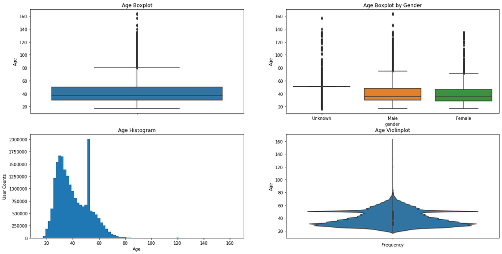

```python
# Exlporing "user Age variable through different statistical charts such as boxplot, histogram and violin plot.
base_color = "Blue"
plt.figure(figsize = [20, 10])

plt.subplot(2,2,1)
sb.boxplot(data = df, y = 'user_age')
plt.ylabel("Age")
plt.title("Age Boxplot");


plt.subplot(2, 2, 2)
ax = sb.boxplot(data = df,x="gender", y="user_age")
plt.ylabel("Age")
plt.title("Age Boxplot by Gender");


plt.subplot(2, 2, 3)
bins = np.arange(df.user_age.min()-2, df.user_age.max()+2,2)
plt.hist(df.user_age, bins = bins)
plt.xlabel("Age")
plt.ylabel("User Counts")
plt.title("Age Histogram");

plt.subplot(2, 2, 4)
sb.violinplot(data = df, y = 'user_age')
plt.ylabel("Age")
plt.xlabel("Frequency")
plt.title("Age Violinplot");
```